# Movie Analysis Project

> DS 220

> Section 555V

> Dimitri Nearchos

## Dataset Overview

The dataset below a preprocessed version of the [The Ultimate 1Million Movies Dataset (TMDB + IMdb)](https://www.kaggle.com/datasets/alanvourch/tmdb-movies-daily-updates) by Alan Vourc'h. The processing script can be found at [`oridim/ds220-pandas-project/process_datasets.py`](https://github.com/oridim/ds220-pandas-project/process_datasets.py). All it does is:

- Project specific needed fields for the analysis found in this Jupyter notebook.
- Strip out rows with missing column data.
- Cleans up column data to remove any potential needed error handling from the Jupyter notebook.
- Normalize column keys.
- Limit the rows to only English (the language, not the British) movies that have been already released.
- Limit the rows to only movies that had a theatrical release (i.e. no made-for-TV movies).

> **INSTRUCTIONS**: Click the play icon on the following two code cells to see the sample top 25 movies by box office revenue.

```python
# IMPORTANT: Run this code cell before all other code cells!

import pandas as pd
import matplotlib.pyplot as plt
import matplotlib.ticker as mtick

df = pd.read_csv("./datasets/oridim.imdb.cleaned.csv")

# Genres are comma-delimited values that need to be preprocessed into an array of strings.
df["genres"] = df["genres"].str.split(",")


def format_runtime(minutes):
    """Formats minute runtime lengths into X hrs Y mins."""

    minutes = int(minutes)
    hours = minutes // 60
    minutes = minutes % 60

    return f"{hours} hrs {minutes} mins"


def format_output(df):
    """
    A formatting help to tell Pandas to format columns representing
    money and runtime durations into user-friendly strings.
    """

    return df.style.format(
        {
            "budget": "$ {:,.2f}",
            "box_office": "$ {:,.2f}",
            "rating": "{:.2f}",
            "runtime": format_runtime,
        }
    )
```

```python
# Sorts by box office revenue for the top 25 movies.

sorted = df.sort_values(by="box_office", ascending=False)
format_output(sorted.head(25))
```

|  | id | title | rating | box_office | budget | runtime | genres |
| --- | --- | --- | --- | --- | --- | --- | --- |
| 20986 | tt1630029 | Avatar: The Way of Water | 7.50 | $ 2,320,250,281.00 | $ 460,000,000.00 | 3 hrs 12 mins | ['action', 'adventure', 'science fiction'] |
| 31741 | tt2488496 | Star Wars: The Force Awakens | 7.80 | $ 2,068,223,624.00 | $ 245,000,000.00 | 2 hrs 16 mins | ['action', 'adventure', 'science fiction'] |
| 101034 | tt22022452 | Inside Out 2 | 7.50 | $ 1,698,863,816.00 | $ 200,000,000.00 | 1 hrs 37 mins | ['adventure', 'animation', 'comedy', 'family'] |
| 107075 | tt12245382 | After Quarentine | 5.30 | $ 1,680,440,676.00 | $ 5.00 | 1 hrs 30 mins | ['comedy', 'documentary', 'drama', 'romance'] |
| 31114 | tt0369610 | Jurassic World | 6.90 | $ 1,671,537,444.00 | $ 150,000,000.00 | 2 hrs 4 mins | ['action', 'adventure', 'science fiction', 'thriller'] |
| 66314 | tt6105098 | The Lion King | 6.80 | $ 1,662,020,819.00 | $ 260,000,000.00 | 1 hrs 58 mins | ['adventure', 'animation', 'drama', 'family'] |
| 59974 | tt1745960 | Top Gun: Maverick | 8.20 | $ 1,488,732,821.00 | $ 170,000,000.00 | 2 hrs 11 mins | ['action', 'drama'] |
| 56063 | tt4520988 | Frozen II | 6.80 | $ 1,453,683,476.00 | $ 150,000,000.00 | 1 hrs 43 mins | ['adventure', 'animation', 'comedy', 'family', 'fantasy'] |
| 58085 | tt1517268 | Barbie | 6.80 | $ 1,445,638,421.00 | $ 145,000,000.00 | 1 hrs 54 mins | ['adventure', 'comedy'] |
| 25673 | tt2395427 | Avengers: Age of Ultron | 7.30 | $ 1,405,403,694.00 | $ 365,000,000.00 | 2 hrs 21 mins | ['action', 'adventure', 'science fiction'] |
| 74349 | tt6718170 | The Super Mario Bros. Movie | 7.00 | $ 1,362,000,000.00 | $ 100,000,000.00 | 1 hrs 33 mins | ['adventure', 'animation', 'comedy', 'family'] |
| 3067 | tt1201607 | Harry Potter and the Deathly Hallows: Part 2 | 8.10 | $ 1,341,511,219.00 | $ 125,000,000.00 | 2 hrs 10 mins | ['adventure', 'fantasy'] |
| 77084 | tt6263850 | Deadpool & Wolverine | 7.60 | $ 1,338,073,645.00 | $ 200,000,000.00 | 2 hrs 8 mins | ['action', 'comedy', 'science fiction'] |
| 36377 | tt2527336 | Star Wars: The Last Jedi | 6.90 | $ 1,332,698,830.00 | $ 200,000,000.00 | 2 hrs 32 mins | ['action', 'adventure', 'science fiction'] |
| 27119 | tt2294629 | Frozen | 7.40 | $ 1,274,219,009.00 | $ 150,000,000.00 | 1 hrs 42 mins | ['adventure', 'animation', 'family', 'fantasy'] |
| 47462 | tt3606756 | Incredibles 2 | 7.50 | $ 1,242,805,359.00 | $ 200,000,000.00 | 1 hrs 58 mins | ['action', 'adventure', 'animation', 'family'] |
| 19402 | tt1300854 | Iron Man 3 | 7.10 | $ 1,215,577,205.00 | $ 200,000,000.00 | 2 hrs 10 mins | ['action', 'adventure', 'science fiction'] |
| 39847 | tt2293640 | Minions | 6.40 | $ 1,159,457,503.00 | $ 74,000,000.00 | 1 hrs 31 mins | ['adventure', 'animation', 'comedy', 'family'] |
| 52646 | tt1477834 | Aquaman | 6.80 | $ 1,152,028,393.00 | $ 160,000,000.00 | 2 hrs 23 mins | ['action', 'adventure', 'fantasy'] |
| 52850 | tt4154664 | Captain Marvel | 6.80 | $ 1,131,416,446.00 | $ 152,000,000.00 | 2 hrs 4 mins | ['action', 'adventure', 'science fiction'] |
| 11391 | tt1399103 | Transformers: Dark of the Moon | 6.20 | $ 1,123,794,079.00 | $ 195,000,000.00 | 2 hrs 34 mins | ['action', 'adventure', 'science fiction'] |
| 39 | tt0167260 | The Lord of the Rings: The Return of the King | 9.00 | $ 1,118,888,979.00 | $ 94,000,000.00 | 3 hrs 21 mins | ['action', 'adventure', 'fantasy'] |
| 11201 | tt1074638 | Skyfall | 7.80 | $ 1,108,594,176.00 | $ 200,000,000.00 | 2 hrs 23 mins | ['action', 'adventure', 'thriller'] |
| 14935 | tt1345836 | The Dark Knight Rises | 8.40 | $ 1,081,041,287.00 | $ 250,000,000.00 | 2 hrs 45 mins | ['action', 'crime', 'drama', 'thriller'] |
| 71981 | tt7286456 | Joker | 8.30 | $ 1,078,958,629.00 | $ 55,000,000.00 | 2 hrs 2 mins | ['crime', 'drama', 'thriller'] |

> **INSTRUCTIONS**: Click the play icon in the below code cell to see how many movies are in the dataset.

```python
print(f"There are {len(df):,} movies in the dataset.")
```

```
There are 114,051 movies in the dataset.
```

## Framing of the Analysis

None of the questions being asked in this notebook are really of much importance. This analysis does not provide world-changing healthcare insights, for instance. However, these of just some questions I have always wondered about film statistics. And this seemed like the perfect time to figure some of these out.

## Live Action vs. Animation

Animated movies are often thought to some that they generate more buzz due to factors such as:

- More artistically driven given the crew behind are creating a whole world from scratch.
- More financial reach due to the parents of the youth culture-driven model of filmmaking.
- etc.

Is this true, however?

### Distribution

> Q: What is the distribution of live-action films vs. animation films?

Animation is generally a more work intensive process. Not only do artists have to create their own world from scratch, they *also* have to physically create it from scratch. Features like furry textures on animals or the reflection of light off shiny surfaces require the artists to put in detailed work. Compared to just recording those things happening naturally with a camera.

Therefore, for the expected return vs. box office revenue, I expect there to be significantly less animated movies than there are live-action.

> **INSTRUCTIONS**: Click the play icon on the code cell below.

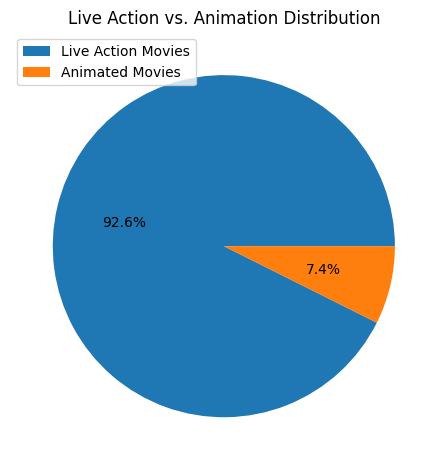

```python
# Creating a series which entries are grouped by either being an animated film or not.
has_animation = df["genres"].apply(lambda genres: "animation" in genres)

# Create a series which gets the count of each grouping.
animation_count = has_animation.value_counts()

animation_counts = animation_count.to_frame(name="Count")
animation_counts.index = animation_counts.index.map(
    {
        True: "Animated Movies",
        False: "Live Action Movies",
    }
)

# Render a pie chart to show the percentage distribution.
plot = animation_counts.plot.pie(
    title="Live Action vs. Animation Distribution",
    y="Count",
    autopct="%1.1f%%",
    labels=None,
    ylabel="",
)

plt.tight_layout()
plt.show()
```

I expected the number of animated movies to be lower. But I did not expect there to only be `~7%` of animated movies total in the dataset. The results, however, do fit my stated expectations.

### Box Office Revenues

> Q: What are the box office revenues on average for each category of film?

Given that number of live-action films is significantly more than animated films, the animated films should be of higher return on average, right? My assumption is due to there should be less dilution of the animated category of films since there is significantly less volume.

> **INSTRUCTIONS**: Click the play icons of each cell below in sequence as they complete.

```python
has_animation = df["genres"].apply(lambda genres: "animation" in genres)


def render_top_averages(n):
    """
        Renders a bar chart showing the top-N box office average revenues
        between each category of filmmaking.
    """

    # Create a new grouped dataframe which calculates the average of
    # animated and live-action movies, respectively.
    #
    # The new dataframe only takes the largest n number of titles from
    # each category.
    box_office_averages = df.groupby(has_animation)["box_office"].apply(
        lambda series: series.nlargest(n).mean()
    )

    box_office_averages.index = box_office_averages.index.map(
        {
            True: "Animated Movies",
            False: "Live Action Movies",
        }
    )

    # Render a bar chart to show the raw averages of each category.
    plot = box_office_averages.plot.bar(
        title=f"Live Action vs. Animation Box Office Averages (Top {n})",
        xlabel="",
        ylabel="Average Box Office ($)",
        rot=0,
    )

    # To create a "zoomed in" bar chart, we are setting the limits of
    # the y-axis to the maximum and minimum averages. Along with some
    # minor padding for a sense of scale.
    min_average = box_office_averages.min()
    max_average = box_office_averages.max()

    y_range = max_average - min_average
    y_padding = y_range * 0.10

    plot.set_ylim(bottom=min_average - y_padding, top=max_average + y_padding)

    # Before showing the bar chart, we need to set up money formatting
    # for the y-axis and in-chart values.
    formatter = mtick.StrMethodFormatter("${x:,.2f}")
    plot.yaxis.set_major_formatter(formatter)

    for container in plot.containers:
        plot.bar_label(container, fmt="$ {:,.2f}")

    plt.tight_layout()
    plt.show()
```

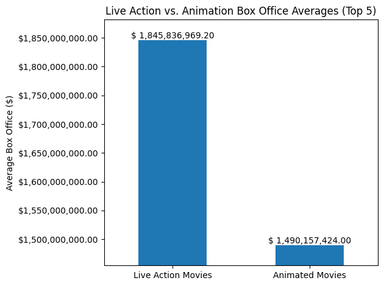

```python
render_top_averages(n=5)
```

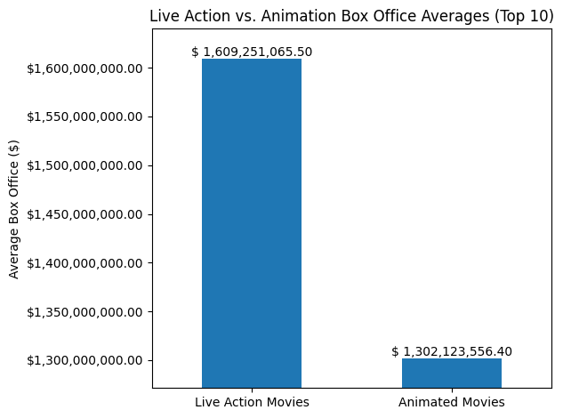

```python
render_top_averages(n=10)
```

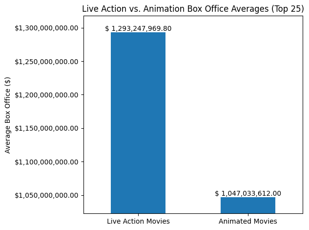

```python
render_top_averages(n=25)
```

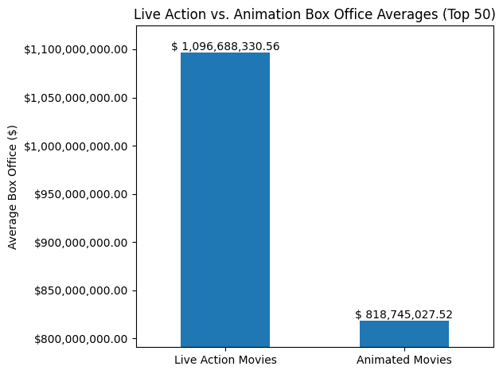

```python
render_top_averages(n=50)
```

While the averages do shift as more entries are added, the delta between each category of movie *barely budges*. So, even as we dilute the averages, the animated movies just overall make less money on average.

### Budgets

> Q: Do animation movies have larger budgets on average?

Like I mentioned before, I presume that do to all the from-scratch work required of animated films, that they would have larger budgets on average. But, is this true?

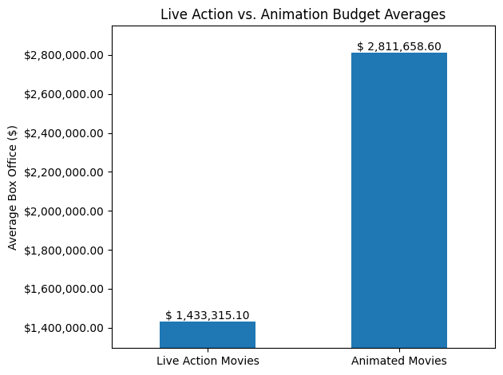

```python
has_animation = df["genres"].apply(lambda genres: "animation" in genres)

budget_averages = df.groupby(has_animation)["budget"].mean()

budget_averages.index = budget_averages.index.map(
    {
        True: "Animated Movies",
        False: "Live Action Movies",
    }
)

plot = budget_averages.plot.bar(
    title=f"Live Action vs. Animation Budget Averages",
    xlabel="",
    ylabel="Average Box Office ($)",
    rot=0,
)

min_average = budget_averages.min()
max_average = budget_averages.max()

y_range = max_average - min_average
y_padding = y_range * 0.10

plot.set_ylim(bottom=min_average - y_padding, top=max_average + y_padding)

formatter = mtick.StrMethodFormatter("${x:,.2f}")
plot.yaxis.set_major_formatter(formatter)

for container in plot.containers:
    plot.bar_label(container, fmt="$ {:,.2f}")

plt.tight_layout()
plt.show()
```

My expectation was proven from this dataset. However, it was proven by a whopping `~49%` difference between the two averages!

## Genre Differences

### Distribution

> Q: What is the distributions of movie genres?

When I think of movie genre distribution, I think of the top action and drama movies. And this might be my superhero loving side showing but... I *would* think that action movies are the top movie. But, is that true?

> **NOTE**: The following charts regarding genre *DO NOT* try to isolate movies by their primary genre. Meaning, a movie that is an action and a drama can be counted for both.

> **INSTRUCTIONS**: Click on the following code block's play icon to generate the pie chart.

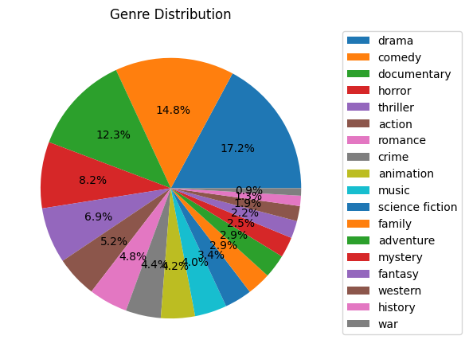

```python
# Create a new dataframe where genre tags are flattened.
# ex. `[["drama", "horror"], ["comedy", "drama"]]`
# -> `["drama", "horror", "comedy", "drama"]`
exploded_genres = df.explode("genres")

# Create a new series of the number of hits for each
# found genre.
genre_counts = exploded_genres["genres"].value_counts()

plot = genre_counts.plot.pie(
    title="Genre Distribution", autopct="%1.1f%%", legend=True, labels=None, ylabel=""
)

legend = plot.get_legend()

# The legend is too long with all the different genres. So,
# we need to move them off to the right.
plt.setp(legend, bbox_to_anchor=(1.01, 1.0))

plt.tight_layout()
plt.show()
```

Wow! I was not really expecting action to not only not be number 1 or number 2 slot, but action was also not even in the top 5! I wonder how much the dataset not isolating for primary genre counts towards that? Maybe there are too many drama action films that are ballooning the drama film count.

There is also the fact that as time as progressed, tastes have changed. For instance, from what I remember from film history class, up until the 70s if your film did not have a musical portion it was considered dead on arrival.

So, for instance, as we have progressed through time, the amount of musical has decreased because it is no longer Hollywood convention to mandate them in every film. And in recent times, we have been getting more drama heavy. Which is especially important context to consider. Since, every year is the most movies ever made per year! Probably.

### Box Office Revenues

> Q: What are the box office revenue averages for each genre of film?

Now one of the things I have always heard is that horror movies, in particular, do not do well at the box office. Is this true?

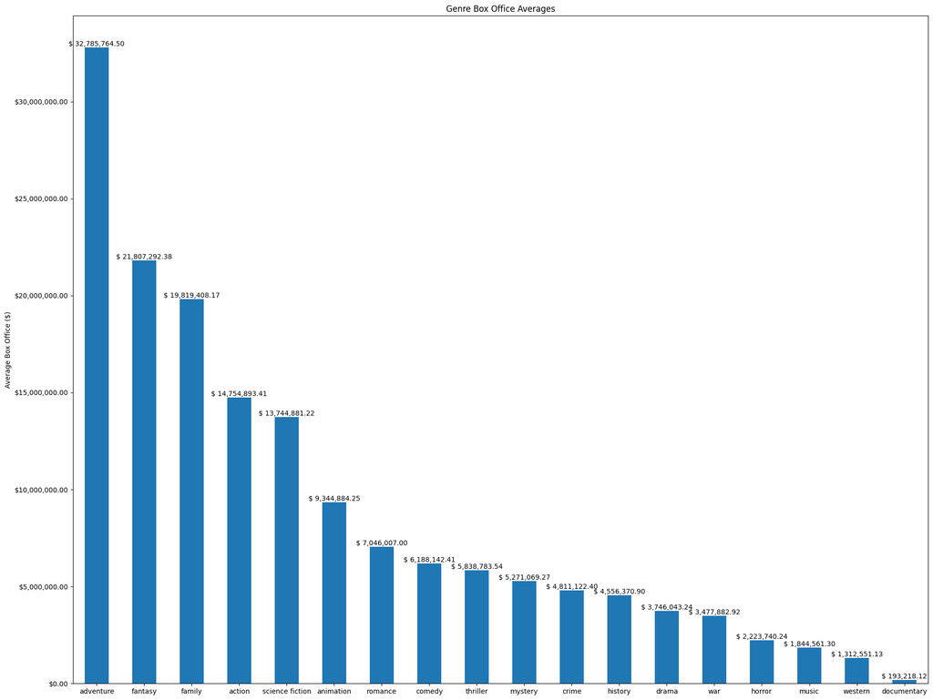

```python
exploded_genres = df.explode("genres")

# After flattening the genres, we get group the dataset by the
# genres and calculate the mean by box office revenue.
box_office_averages = (
    exploded_genres.groupby("genres")["box_office"].mean().sort_values(ascending=False)
)

plot = box_office_averages.plot.bar(
    title=f"Genre Box Office Averages",
    figsize=(19.2, 14.4),
    xlabel="",
    ylabel="Average Box Office ($)",
    rot=0,
)

formatter = mtick.StrMethodFormatter("${x:,.2f}")
plot.yaxis.set_major_formatter(formatter)

for container in plot.containers:
    plot.bar_label(container, fmt="$ {:,.2f}")

plt.tight_layout()
plt.show()
```

Horror is pretty far down the chart and by a wide margin too. So, the things I have heard over the years about the horror genre seem spot on. Also, musicals are third from the bottom of the rankings. It seems like them falling out of favor has had an effect.

I am not surprised about adventure doing so well. Usually, in my experience, adventure films are treated as big tent pole releases where the family can go watch a "theme park ride" of a movie. Avatar: The Way of the Water is the top box office grossing movie. Which you can see at the top of this notebook. It grossed about `~2.32B`. That movie is the top grossing movie *and* an adventure movie.

### Budgets

> Q: What are the budget averages for each genre of film?

Going back to horror movies, I have also heard they are generally done on shoestring budgets compared to the big blockbusters. Mostly due to them being more of an auteur or highly personal taste of the director experiences. Let us see how well that assumption holds.

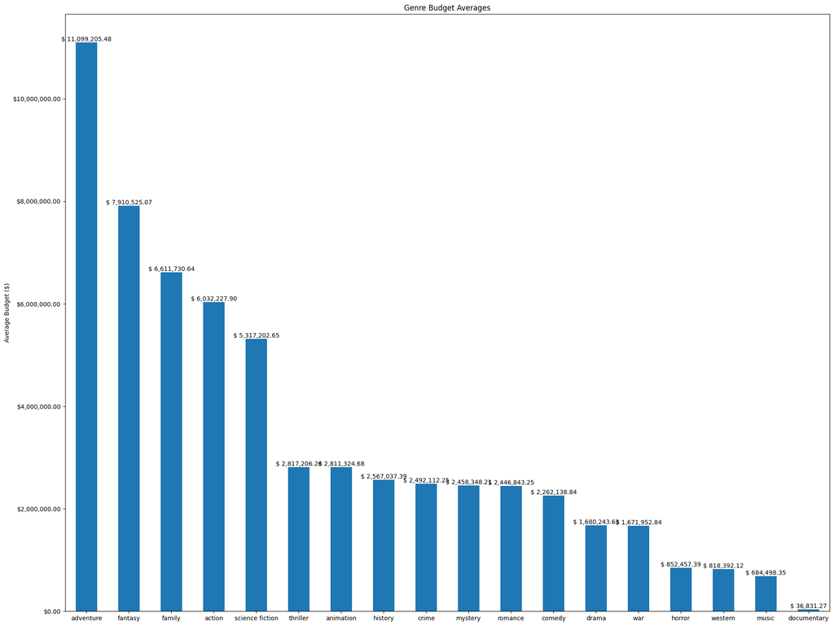

```python
exploded_genres = df.explode("genres")

box_office_averages = (
    exploded_genres.groupby("genres")["budget"].mean().sort_values(ascending=False)
)

plot = box_office_averages.plot.bar(
    title=f"Genre Budget Averages",
    figsize=(19.2, 14.4),
    xlabel="",
    ylabel="Average Budget ($)",
    rot=0,
)

formatter = mtick.StrMethodFormatter("${x:,.2f}")
plot.yaxis.set_major_formatter(formatter)

for container in plot.containers:
    plot.bar_label(container, fmt="$ {:,.2f}")

plt.tight_layout()
plt.show()
```

Literally, horror movies are the same position as last time. Fourth from the bottom in the ranking. And, I never thought really thought about it before, but documentaries really are just going out there and shooting the world with a camera. There are usually not really any special effects or that sort of thing to speak of. *Of course* documentary films have the least amount of budget!